# Introduction

In this project, you will build a neural network of your own design to evaluate the CIFAR-10 dataset. Our target accuracy is 70%, but any accuracy over 50% is a great start. Some of the benchmark results on CIFAR-10 include:

78.9% Accuracy | [Deep Belief Networks; Krizhevsky, 2010](https://www.cs.toronto.edu/~kriz/conv-cifar10-aug2010.pdf)

90.6% Accuracy | [Maxout Networks; Goodfellow et al., 2013](https://arxiv.org/pdf/1302.4389.pdf)

96.0% Accuracy | [Wide Residual Networks; Zagoruyko et al., 2016](https://arxiv.org/pdf/1605.07146.pdf)

99.0% Accuracy | [GPipe; Huang et al., 2018](https://arxiv.org/pdf/1811.06965.pdf)

98.5% Accuracy | [Rethinking Recurrent Neural Networks and other Improvements for ImageClassification; Nguyen et al., 2020](https://arxiv.org/pdf/2007.15161.pdf)

Research with this dataset is ongoing. Notably, many of these networks are quite large and quite expensive to train.

## Imports

```python
## This cell contains the essential imports you will need – DO NOT CHANGE THE CONTENTS! ##
import torch
import torch.nn as nn
import torch.nn.functional as F
import torch.optim as optim
import torchvision
import torchvision.transforms as transforms
import matplotlib.pyplot as plt
import numpy as np

# Additional imports for training the models
from torchvision import models
from collections import OrderedDict
```

##### Note

I am using Python 3.12.7 for this excercice

## Load the Dataset

Specify your transforms as a list first. The transforms module is already loaded as `transforms`.

CIFAR-10 is fortunately included in the torchvision module. Then, you can create your dataset using the `CIFAR10` object from `torchvision.datasets` ([the documentation is available here](https://pytorch.org/docs/stable/torchvision/datasets.html#cifar)). Make sure to specify `download=True`!

Once your dataset is created, you'll also need to define a `DataLoader` from the `torch.utils.data` module for both the train and the test set.

The link is dead but I found it anyway

```python
# Define transforms
## YOUR CODE HERE ##
train_transform = transforms.Compose([
    transforms.Resize(224),
    transforms.RandomHorizontalFlip(),
    transforms.ToTensor(),
    transforms.Normalize((0.485, 0.456, 0.406), (0.229, 0.224, 0.225))  # TThose are the ImageNet means and std deviations
])

# In the test we do not apply data augmentation, so we only resize and normalize the images to get a real world feel.
test_transform = transforms.Compose([
    transforms.Resize(224),
    transforms.ToTensor(),
    transforms.Normalize((0.485, 0.456, 0.406), (0.229, 0.224, 0.225))  # TThose are the ImageNet means and std deviations
])


# Create training set and define training dataloader
## YOUR CODE HERE ##
trainset = torchvision.datasets.CIFAR10(root='./data', train=True, download=True, transform=train_transform)

# Create test set and define test dataloader
testset = torchvision.datasets.CIFAR10(root='./data', train=False, download=True, transform=test_transform)

# Datalaoders
trainloader = torch.utils.data.DataLoader(trainset, batch_size=64, shuffle=True)
testloader = torch.utils.data.DataLoader(testset, batch_size=64, shuffle=False)

# The 10 classes in the dataset
classes = ('plane', 'car', 'bird', 'cat', 'deer', 'dog', 'frog', 'horse', 'ship', 'truck')
```

## Explore the Dataset

Using matplotlib, numpy, and torch, explore the dimensions of your data.

You can view images using the `show5` function defined below – it takes a data loader as an argument. Remember that normalized images will look really weird to you! You may want to try changing your transforms to view images. Typically using no transforms other than `toTensor()` works well for viewing – but not as well for training your network. If `show5` doesn't work, go back and check your code for creating your data loaders and your training/test sets.

```python
%matplotlib inline
def show5(img_loader):
    dataiter = iter(img_loader)

    batch = next(dataiter)
    labels = batch[1][0:5]
    images = batch[0][0:5]
    for i in range(5):
        print(classes[labels[i]])

        image = images[i].numpy()
        plt.imshow(image.T)
        plt.show()
```

```
Training Samples Lentgh:  50000
Test Samples Lenght:  10000
Number of classes:  10
Image batch shape:  torch.Size([64, 3, 224, 224])
Label batch shape:  torch.Size([64])
frog
```

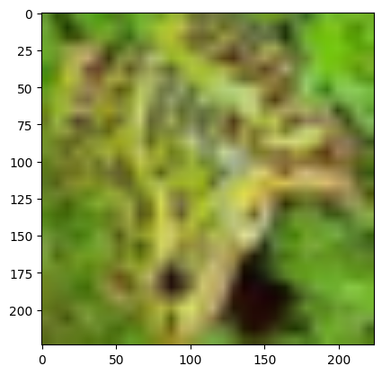

```
car
```

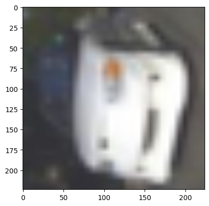

```
frog
```

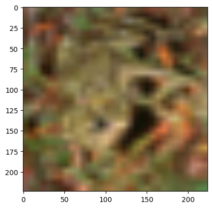

```
horse
```

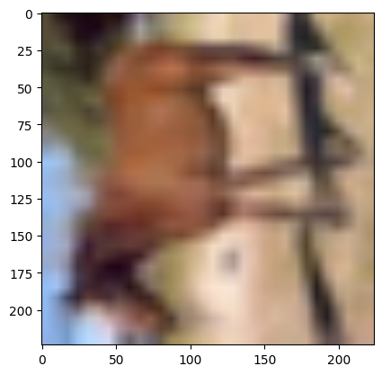

```
plane
```

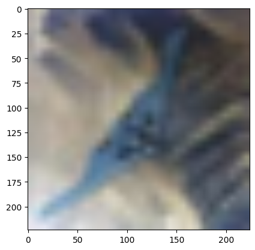

```
Clipping input data to the valid range for imshow with RGB data ([0..1] for floats or [0..255] for integers). Got range [-1.8952821..2.5877128].
```

```
cat
```

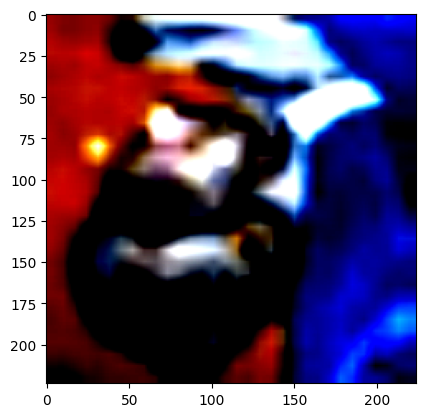

```
Clipping input data to the valid range for imshow with RGB data ([0..1] for floats or [0..255] for integers). Got range [-2.117904..2.5005665].
```

```
ship
```

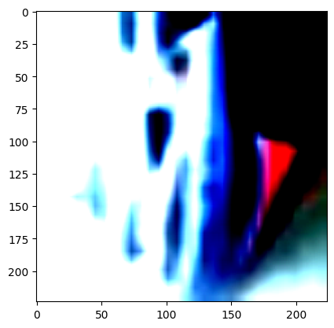

```
ship
```

```
Clipping input data to the valid range for imshow with RGB data ([0..1] for floats or [0..255] for integers). Got range [-2.0494049..2.5877128].
```

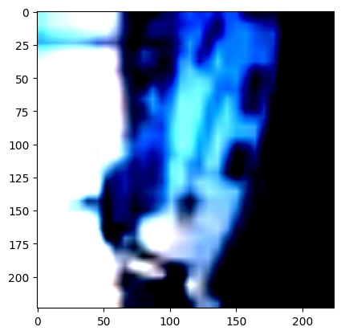

```
Clipping input data to the valid range for imshow with RGB data ([0..1] for floats or [0..255] for integers). Got range [-1.4842881..2.2739873].
```

```
plane
```

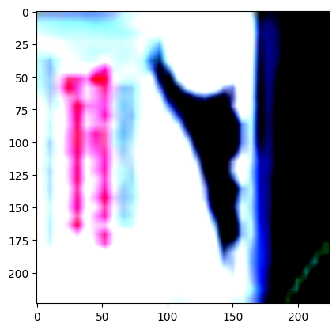

```
frog
```

```
Clipping input data to the valid range for imshow with RGB data ([0..1] for floats or [0..255] for integers). Got range [-1.9980307..1.8158263].
```

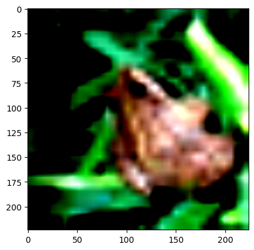

```python
# Explore data
## YOUR CODE HERE ##
print("Training Samples Lentgh: ", len(trainset))
print("Test Samples Lenght: ", len(testset))
print("Number of classes: ", len(classes))

images, labels = next(iter(trainloader))
print("Image batch shape: ", images.shape)
print("Label batch shape: ", labels.shape)

# I create as speciallized view dataloader to show some images as the normalization makes the images look weird.
view_transforms = transforms.Compose([
    transforms.Resize(224),
    transforms.ToTensor(),                          # only resize and to tensor, no normalization otherweise

])
view_set = torchvision.datasets.CIFAR10(
    root='./data', train=False, download=True, transform=view_transforms,
)
view_loader = torch.utils.data.DataLoader(view_set, batch_size=32, shuffle=True)
show5(view_loader)

# compare with the normalized images
show5(testloader)
```

#### Inspeciton

WE see that the normalised images have way higher saturation und i guess higher contrast so they look like old isntagram filters. But we see that both view and test / train dataloader show pictures the clipping input warning is normal.

## Build your Neural Network

Using the layers in `torch.nn` (which has been imported as `nn`) and the `torch.nn.functional` module (imported as `F`), construct a neural network based on the parameters of the dataset. Feel free to construct a model of any architecture – feedforward, convolutional, or even something more advanced!

```python
## YOUR CODE HERE ##

# I am using nn.Sequential to build the classifier head so I am able to strip the head of the resnet model and replace it with my own. I am using a simple feed forward network with one hidden layer and ReLU activation function. The output layer has 10 neurons, one for each class in the CIFAR-10 dataset.

model = models.resnet18(pretrained=True)

for param in model.parameters():
    param.requires_grad = False



classifier = nn.Sequential(OrderedDict([
    ('fc1',        nn.Linear(512, 256)),
    ('relu',       nn.ReLU()),
    ('dropout',    nn.Dropout(p=0.2)),
    ('fc2',        nn.Linear(256, 10)),
    ('logsoftmax', nn.LogSoftmax(dim=1)),
]))

# we use a softmax function in the output layer later because we want to get the probabilities of each class and not just the raw scores, later int eh model.
# The logsoftmax is used because it is more stable than the softmax function and it is better for backpropagation because we need logps anyway.

print(model)
print(classifier)

""")
  (avgpool): AdaptiveAvgPool2d(output_size=(1, 1))
  (fc): Linear(in_features=512, out_features=1000, bias=True)
)"""
# THis is the original resnet18 model, we will now replace the fc layer with our own classifier head.
```

```
ResNet(
  (conv1): Conv2d(3, 64, kernel_size=(7, 7), stride=(2, 2), padding=(3, 3), bias=False)
  (bn1): BatchNorm2d(64, eps=1e-05, momentum=0.1, affine=True, track_running_stats=True)
  (relu): ReLU(inplace=True)
  (maxpool): MaxPool2d(kernel_size=3, stride=2, padding=1, dilation=1, ceil_mode=False)
  (layer1): Sequential(
    (0): BasicBlock(
      (conv1): Conv2d(64, 64, kernel_size=(3, 3), stride=(1, 1), padding=(1, 1), bias=False)
      (bn1): BatchNorm2d(64, eps=1e-05, momentum=0.1, affine=True, track_running_stats=True)
      (relu): ReLU(inplace=True)
      (conv2): Conv2d(64, 64, kernel_size=(3, 3), stride=(1, 1), padding=(1, 1), bias=False)
      (bn2): BatchNorm2d(64, eps=1e-05, momentum=0.1, affine=True, track_running_stats=True)
    )
    (1): BasicBlock(
      (conv1): Conv2d(64, 64, kernel_size=(3, 3), stride=(1, 1), padding=(1, 1), bias=False)
      (bn1): BatchNorm2d(64, eps=1e-05, momentum=0.1, affine=True, track_running_stats=True)
      (relu): ReLU(inplace=True)
      (conv2): Conv2d(64, 64, kernel_size=(3, 3), stride=(1, 1), padding=(1, 1), bias=False)
      (bn2): BatchNorm2d(64, eps=1e-05, momentum=0.1, affine=True, track_running_stats=True)
    )
  )
  (layer2): Sequential(
    (0): BasicBlock(
      (conv1): Conv2d(64, 128, kernel_size=(3, 3), stride=(2, 2), padding=(1, 1), bias=False)
      (bn1): BatchNorm2d(128, eps=1e-05, momentum=0.1, affine=True, track_running_stats=True)
      (relu): ReLU(inplace=True)
      (conv2): Conv2d(128, 128, kernel_size=(3, 3), stride=(1, 1), padding=(1, 1), bias=False)
      (bn2): BatchNorm2d(128, eps=1e-05, momentum=0.1, affine=True, track_running_stats=True)
      (downsample): Sequential(
        (0): Conv2d(64, 128, kernel_size=(1, 1), stride=(2, 2), bias=False)
        (1): BatchNorm2d(128, eps=1e-05, momentum=0.1, affine=True, track_running_stats=True)
      )
    )
    (1): BasicBlock(
      (conv1): Conv2d(128, 128, kernel_size=(3, 3), stride=(1, 1), padding=(1, 1), bias=False)
      (bn1): BatchNorm2d(128, eps=1e-05, momentum=0.1, affine=True, track_running_stats=True)
      (relu): ReLU(inplace=True)
      (conv2): Conv2d(128, 128, kernel_size=(3, 3), stride=(1, 1), padding=(1, 1), bias=False)
      (bn2): BatchNorm2d(128, eps=1e-05, momentum=0.1, affine=True, track_running_stats=True)
    )
```

[output cut: 36 more lines]

```
      (relu): ReLU(inplace=True)
      (conv2): Conv2d(512, 512, kernel_size=(3, 3), stride=(1, 1), padding=(1, 1), bias=False)
      (bn2): BatchNorm2d(512, eps=1e-05, momentum=0.1, affine=True, track_running_stats=True)
    )
  )
  (avgpool): AdaptiveAvgPool2d(output_size=(1, 1))
  (fc): Linear(in_features=512, out_features=1000, bias=True)
)
Sequential(
  (fc1): Linear(in_features=512, out_features=256, bias=True)
  (relu): ReLU()
  (dropout): Dropout(p=0.2, inplace=False)
  (fc2): Linear(in_features=256, out_features=10, bias=True)
  (logsoftmax): LogSoftmax(dim=1)
)
```

Specify a loss function and an optimizer, and instantiate the model.

If you use a less common loss function, please note why you chose that loss function in a comment.

```python
## YOUR CODE HERE ##
model.fc = classifier

print(model)
```

```
ResNet(
  (conv1): Conv2d(3, 64, kernel_size=(7, 7), stride=(2, 2), padding=(3, 3), bias=False)
  (bn1): BatchNorm2d(64, eps=1e-05, momentum=0.1, affine=True, track_running_stats=True)
  (relu): ReLU(inplace=True)
  (maxpool): MaxPool2d(kernel_size=3, stride=2, padding=1, dilation=1, ceil_mode=False)
  (layer1): Sequential(
    (0): BasicBlock(
      (conv1): Conv2d(64, 64, kernel_size=(3, 3), stride=(1, 1), padding=(1, 1), bias=False)
      (bn1): BatchNorm2d(64, eps=1e-05, momentum=0.1, affine=True, track_running_stats=True)
      (relu): ReLU(inplace=True)
      (conv2): Conv2d(64, 64, kernel_size=(3, 3), stride=(1, 1), padding=(1, 1), bias=False)
      (bn2): BatchNorm2d(64, eps=1e-05, momentum=0.1, affine=True, track_running_stats=True)
    )
    (1): BasicBlock(
      (conv1): Conv2d(64, 64, kernel_size=(3, 3), stride=(1, 1), padding=(1, 1), bias=False)
      (bn1): BatchNorm2d(64, eps=1e-05, momentum=0.1, affine=True, track_running_stats=True)
      (relu): ReLU(inplace=True)
      (conv2): Conv2d(64, 64, kernel_size=(3, 3), stride=(1, 1), padding=(1, 1), bias=False)
      (bn2): BatchNorm2d(64, eps=1e-05, momentum=0.1, affine=True, track_running_stats=True)
    )
  )
  (layer2): Sequential(
    (0): BasicBlock(
      (conv1): Conv2d(64, 128, kernel_size=(3, 3), stride=(2, 2), padding=(1, 1), bias=False)
      (bn1): BatchNorm2d(128, eps=1e-05, momentum=0.1, affine=True, track_running_stats=True)
      (relu): ReLU(inplace=True)
      (conv2): Conv2d(128, 128, kernel_size=(3, 3), stride=(1, 1), padding=(1, 1), bias=False)
      (bn2): BatchNorm2d(128, eps=1e-05, momentum=0.1, affine=True, track_running_stats=True)
      (downsample): Sequential(
        (0): Conv2d(64, 128, kernel_size=(1, 1), stride=(2, 2), bias=False)
        (1): BatchNorm2d(128, eps=1e-05, momentum=0.1, affine=True, track_running_stats=True)
      )
    )
    (1): BasicBlock(
      (conv1): Conv2d(128, 128, kernel_size=(3, 3), stride=(1, 1), padding=(1, 1), bias=False)
      (bn1): BatchNorm2d(128, eps=1e-05, momentum=0.1, affine=True, track_running_stats=True)
      (relu): ReLU(inplace=True)
      (conv2): Conv2d(128, 128, kernel_size=(3, 3), stride=(1, 1), padding=(1, 1), bias=False)
      (bn2): BatchNorm2d(128, eps=1e-05, momentum=0.1, affine=True, track_running_stats=True)
    )
```

[output cut: 35 more lines]

```
      (bn1): BatchNorm2d(512, eps=1e-05, momentum=0.1, affine=True, track_running_stats=True)
      (relu): ReLU(inplace=True)
      (conv2): Conv2d(512, 512, kernel_size=(3, 3), stride=(1, 1), padding=(1, 1), bias=False)
      (bn2): BatchNorm2d(512, eps=1e-05, momentum=0.1, affine=True, track_running_stats=True)
    )
  )
  (avgpool): AdaptiveAvgPool2d(output_size=(1, 1))
  (fc): Sequential(
    (fc1): Linear(in_features=512, out_features=256, bias=True)
    (relu): ReLU()
    (dropout): Dropout(p=0.2, inplace=False)
    (fc2): Linear(in_features=256, out_features=10, bias=True)
    (logsoftmax): LogSoftmax(dim=1)
  )
)
```

```python
#check if cuda is available and which device we are using
device = torch.device("cuda" if torch.cuda.is_available() else "cpu")
print("Using device: ", device)
```

```
Using device:  cuda
```

```python
# Check name of the gpu we are using
if torch.cuda.is_available():
    print("GPU Name: ", torch.cuda.get_device_name(0))
```

```
GPU Name:  NVIDIA GeForce GTX 1660 Ti with Max-Q Design
```

```python
## Load the model to the device
model.to(device)
```

```
ResNet(
  (conv1): Conv2d(3, 64, kernel_size=(7, 7), stride=(2, 2), padding=(3, 3), bias=False)
  (bn1): BatchNorm2d(64, eps=1e-05, momentum=0.1, affine=True, track_running_stats=True)
  (relu): ReLU(inplace=True)
  (maxpool): MaxPool2d(kernel_size=3, stride=2, padding=1, dilation=1, ceil_mode=False)
  (layer1): Sequential(
    (0): BasicBlock(
      (conv1): Conv2d(64, 64, kernel_size=(3, 3), stride=(1, 1), padding=(1, 1), bias=False)
      (bn1): BatchNorm2d(64, eps=1e-05, momentum=0.1, affine=True, track_running_stats=True)
      (relu): ReLU(inplace=True)
      (conv2): Conv2d(64, 64, kernel_size=(3, 3), stride=(1, 1), padding=(1, 1), bias=False)
      (bn2): BatchNorm2d(64, eps=1e-05, momentum=0.1, affine=True, track_running_stats=True)
    )
    (1): BasicBlock(
      (conv1): Conv2d(64, 64, kernel_size=(3, 3), stride=(1, 1), padding=(1, 1), bias=False)
      (bn1): BatchNorm2d(64, eps=1e-05, momentum=0.1, affine=True, track_running_stats=True)
      (relu): ReLU(inplace=True)
      (conv2): Conv2d(64, 64, kernel_size=(3, 3), stride=(1, 1), padding=(1, 1), bias=False)
      (bn2): BatchNorm2d(64, eps=1e-05, momentum=0.1, affine=True, track_running_stats=True)
    )
  )
  (layer2): Sequential(
    (0): BasicBlock(
      (conv1): Conv2d(64, 128, kernel_size=(3, 3), stride=(2, 2), padding=(1, 1), bias=False)
      (bn1): BatchNorm2d(128, eps=1e-05, momentum=0.1, affine=True, track_running_stats=True)
      (relu): ReLU(inplace=True)
      (conv2): Conv2d(128, 128, kernel_size=(3, 3), stride=(1, 1), padding=(1, 1), bias=False)
      (bn2): BatchNorm2d(128, eps=1e-05, momentum=0.1, affine=True, track_running_stats=True)
      (downsample): Sequential(
        (0): Conv2d(64, 128, kernel_size=(1, 1), stride=(2, 2), bias=False)
        (1): BatchNorm2d(128, eps=1e-05, momentum=0.1, affine=True, track_running_stats=True)
      )
    )
    (1): BasicBlock(
      (conv1): Conv2d(128, 128, kernel_size=(3, 3), stride=(1, 1), padding=(1, 1), bias=False)
      (bn1): BatchNorm2d(128, eps=1e-05, momentum=0.1, affine=True, track_running_stats=True)
      (relu): ReLU(inplace=True)
      (conv2): Conv2d(128, 128, kernel_size=(3, 3), stride=(1, 1), padding=(1, 1), bias=False)
      (bn2): BatchNorm2d(128, eps=1e-05, momentum=0.1, affine=True, track_running_stats=True)
    )
```

[output cut: 35 more lines]

```
      (bn1): BatchNorm2d(512, eps=1e-05, momentum=0.1, affine=True, track_running_stats=True)
      (relu): ReLU(inplace=True)
      (conv2): Conv2d(512, 512, kernel_size=(3, 3), stride=(1, 1), padding=(1, 1), bias=False)
      (bn2): BatchNorm2d(512, eps=1e-05, momentum=0.1, affine=True, track_running_stats=True)
    )
  )
  (avgpool): AdaptiveAvgPool2d(output_size=(1, 1))
  (fc): Sequential(
    (fc1): Linear(in_features=512, out_features=256, bias=True)
    (relu): ReLU()
    (dropout): Dropout(p=0.2, inplace=False)
    (fc2): Linear(in_features=256, out_features=10, bias=True)
    (logsoftmax): LogSoftmax(dim=1)
  )
)
```

```python
## Specify the loss function and the optimizer
criterion = nn.NLLLoss() # we use negative log lloss because we are using logsoftmax in the output layer, if we were using softmax we would use nn.CrossEntropyLoss()
optimizer = optim.Adam(model.fc.parameters(), lr=0.001) # we only want to update the parameters of the classifier head, so we pass model.fc.parameters() to the optimizer

print(criterion)
print(optimizer)
```

```
NLLLoss()
Adam (
Parameter Group 0
    amsgrad: False
    betas: (0.9, 0.999)
    capturable: False
    differentiable: False
    eps: 1e-08
    foreach: None
    fused: None
    lr: 0.001
    maximize: False
    weight_decay: 0
)
```

## Running your Neural Network

Use whatever method you like to train your neural network, and ensure you record the average loss at each epoch. Don't forget to use `torch.device()` and the `.to()` method for both your model and your data if you are using GPU!

If you want to print your loss during each epoch, you can use the `enumerate` function and print the loss after a set number of batches. 250 batches works well for most people!

```python
### TRAINING LOOP
# We do not need so many epochs to train the model because we are using a pretrained CC model that has already learned useful features from the ImageNet dataset,
# so we can get good results with just a few epochs of training.

epochs = 5
train_losses = [] # we collect the training losses in this list to plot them later and see how the model is getting better.

for e in range(epochs):
    model.train()
    running_loss = 0.00 # set to 0 initially this will with every epoch also reset.
    for i, (images, labels) in enumerate(trainloader): #we use enumerate to get the index of each batch so we can print the loss every 250 batches.
        images, labels = images.to(device), labels.to(device) # we load the images and labels onto our geforce

        optimizer.zero_grad() # we zero the gradients of the optimizer to avoid accumulation of gradients from the last batch

        logps = model(images) # we get the log probabilities from the model this is because we use LOGsoftmax and not regular softmax
        loss = criterion(logps, labels) # we calculate the loss with out criterion Nllloss
        loss.backward() # we do the backpropagation.
        optimizer.step() # here we optimize the weights.

        running_loss += loss.item() # we add the loss of this turn to the running loss


        if (i + 1) % 250 == 0: # here if the batch index is a multiple of 250 we print out the loss.
            print(f"Epoch {e+1}  Batch {i+1} Loss: {running_loss/(i+1):.3f}") # we print the running average across all batches so far

    avg_loss = running_loss / len(trainloader)
    train_losses.append(avg_loss)
    print(f"Epoch {e+1}/{epochs} - Average Loss: {avg_loss:.4f}")

print("and we are done with training!")
```

[output not shown]

Plot the training loss (and validation loss/accuracy, if recorded).

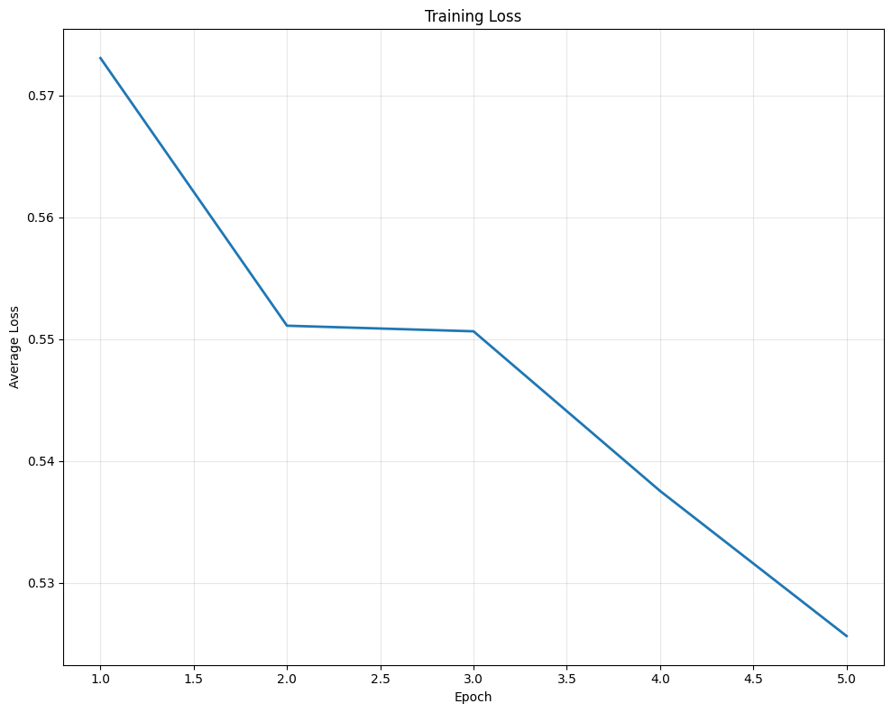

```python
# Matplotlib


plt.figure(figsize=(10, 8))
plt.plot(range(1, len(train_losses) + 1), train_losses, linewidth=2) # we set the range of the x achsis to be from 1 to number of epochs.
plt.xlabel('Epoch')
plt.ylabel('Average Loss')
plt.title('Training Loss')
plt.grid(True, alpha=0.3)
plt.tight_layout()
plt.show()
```

## Testing your model

Using the previously created `DataLoader` for the test set, compute the percentage of correct predictions using the highest probability prediction.

If your accuracy is over 70%, great work! This is a hard task to exceed 70% on.

If your accuracy is under 45%, you'll need to make improvements. Go back and check your model architecture, loss function, and optimizer to make sure they're appropriate for an image classification task.

```python
## Testing our model
# Note: THis is my second attempt with a model, first i tried it with MLP but it was not able to crack the 50% accuracy threshold,
# so I switched to the pretrained resnet18 model! Hopefully we get better results now!
# In a real world setting I would also add more epochs and a validation set to look at the performance of the model avoid overfitting, to save time with an MVP we just test the model on the test set after training it for 5 epochs.

model.eval() # we set the model to evaluation mode
correct = 0
total = 0

with torch.no_grad(): # we do not need to calculate gradients during testing,
    for images, labels in testloader:
        images, labels = images.to(device), labels.to(device) # we load the images and labels onto our geforce

        log_ps = model(images) # log-LL
        ps = torch.exp(log_ps) # we retransform the log ll to normal pp.
        top_p, top_class = ps.topk(1, dim=1) # we get the top class predicted by the model.

        equals = top_class == labels.view(*top_class.shape) # we check if the predicted class is equal to the correct class from the label.
        correct += equals.sum().item() # we add the number of correct predictions to the correct.
        total += labels.size(0) # we add the number of images in this batch to the total.
model.train() # so we dont forget to set back the model to training.

accuracy = 100 * correct / total
print(f"Test Accuracy: {accuracy:.2f}% ({correct}/{total})")
```

```
Test Accuracy: 82.00% (8200/10000)
```

## Saving your model

Using `torch.save`, save your model for future loading.

```python
## YOUR CODE HERE ##

# Its always better to save everything.
"""classifier = nn.Sequential(OrderedDict([
    ('fc1',        nn.Linear(512, 256)),
    ('relu',       nn.ReLU()),
    ('dropout',    nn.Dropout(p=0.2)),
    ('fc2',        nn.Linear(256, 10)),
    ('logsoftmax', nn.LogSoftmax(dim=1)),
]))"""


checkpoint = {
    'model_state_dict': model.state_dict(),
    'optimizer_state_dict': optimizer.state_dict(),
    'train_losses': train_losses,
    'epochs': epochs,
    'criterion': criterion,
    'dropout': 0.2,
    'classes': classes,
    'input_size': 512, #
    'hidden_size': 256,
    'output_size': 10,
}

torch.save(checkpoint, 'cifar10_resnet18_checkpoint.pth')
```

## Make a Recommendation

Based on your evaluation, what is your recommendation on whether to build or buy? Explain your reasoning below.

### Our Model: Transfer Learning on the Cifar10 dataset with a backbone Resnet18

Instead of training our model from the base up, we used an approach that is widely common using an existing model Resnet18 This is known as Transfer Learning. The pretrained model used the imagenet dataset and was trained on 1000 different output classes. We stripped away the old classifier and replaced it by a custom classifier that retrains the model on our 10 classes we are interested in

We used a classifier head with Relu Activation and Dropout to avoid model confusion. In the end we mapped the 512 to 256 in a hidden layer to 10 in our output layer with a Logsoftmax at the end to get the predictions on our 10 classes of interest.

Our training set consisted of 50000 images from the cifar image dataset and our testset was a separate 10000 images.

After only 5 epochs we reached a test accuracy score of 82%. The training was very efficient even with a basic set-up we were able to train the model in under 1 hour!

### Decision: Build

Our decision is strongly towards build. By investing a bit of time we can use the model architecture of our model and add more epochs. To prevent overfitting on the training data we can introduce a validation step to calculate the loss function over time also based on a set the model does not see during training to see where the sweet spot lays and hopefully nudge the models performance even higher.

### Benefits of Building

We can therfore leverage the fact that we have the control over the model intern, and if we want to extand the model to more output units we can do so with minimal effort (if we have a labeled dataset of course)

We also outperform the model which is by itself a strong indicator to use our model instead

Training time is low and even with 5 epochs we already get sufficient results!

```python
## Now we save the notebook output in html
!jupyter nbconvert --to html CIFAR-10_Image_Classifier-STARTER.ipynb
```

```
[NbConvertApp] Converting notebook CIFAR-10_Image_Classifier-STARTER.ipynb to html
[NbConvertApp] WARNING | Alternative text is missing on 11 image(s).
[NbConvertApp] Writing 1670816 bytes to CIFAR-10_Image_Classifier-STARTER.html
```